# Project 1

2023-10-28

*Zuriel Nwankwo (Replace this part with your name)*

For this assignment, we will again be using the `forecast` library.

```r
options(repos = c(CRAN = "https://cloud.r-project.org"))
install.packages("tidyverse")
library("forecast")
library("zoo")
library("ggplot2")
library("dplyr")
library("xts")
library("lubridate")
library("tseries")
```

The dataset is the Market Yield on U.S. Treasury Securities at 10-Year Constant Maturity, Quoted on an Investment Basis.

Source: https://fred.stlouisfed.org/series/GS10

Setting up Time Series Parameters:

```r
#Read Data
data <- read.csv("rates.csv")
date <- as.Date(data$DATE, format = "%Y-%m-%d")
rate <- data$GS10
```

## Data Cleaning

```r
length(rate)
```

```
## [1] 847
```

```r
length(date)
```

```
## [1] 847
```

```r
head(data)
```

```
##         DATE GS10
## 1 1953-04-01 2.83
## 2 1953-05-01 3.05
## 3 1953-06-01 3.11
## 4 1953-07-01 2.93
## 5 1953-08-01 2.95
## 6 1953-09-01 2.87
```

```r
tail(data)
```

```
##           DATE GS10
## 842 2023-05-01 3.57
## 843 2023-06-01 3.75
## 844 2023-07-01 3.90
## 845 2023-08-01 4.17
## 846 2023-09-01 4.38
## 847 2023-10-01 4.80
```

```r
na_count_date <- sum(is.na(date))
na_count_rate <- sum(is.na(rate))
print(na_count_date)
```

```
## [1] 0
```

```r
print(na_count_rate)
```

```
## [1] 0
```

Based on these observations, the data set has no missing values and doesn’t possess mismatched columns either.

## Part A

First, we plot the original data:

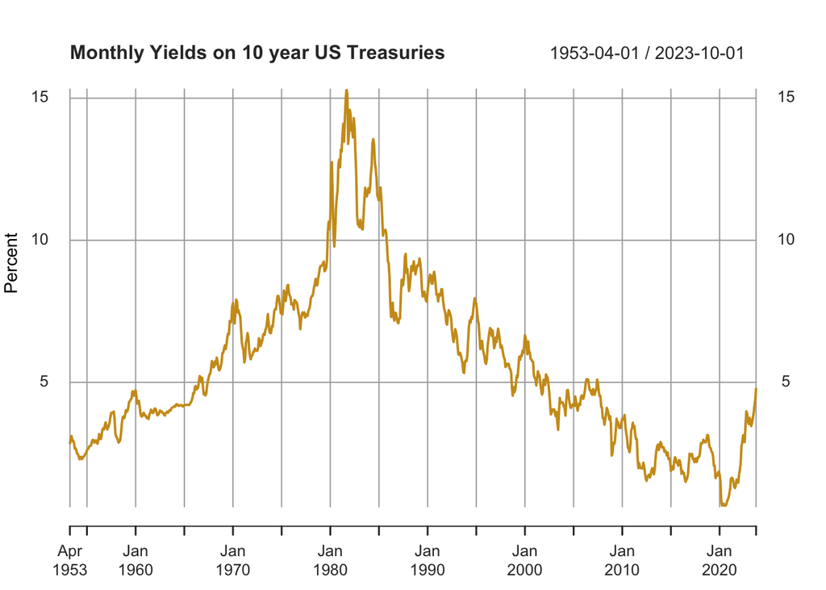

```r
# Create an xts object
rates_xts <- xts(rate, order.by=date)

# Quick plot

par(mar=c(8,8,8,8)) #Set Margins (B, L, T, R)

plot(rates_xts, main = "Monthly Yields on 10 year US Treasuries", col ="goldenrod3", xlab = "Date", ylab ="Percent")
```

ADF Test for Stationarity:

```r
adf.test(rates_xts)
```

```
##
##  Augmented Dickey-Fuller Test
##
## data:  rates_xts
## Dickey-Fuller = -2.0707, Lag order = 9, p-value = 0.5484
## alternative hypothesis: stationary
```

## Part B

- Brief Description:

Stationarity: - The series appears to be non-stationary. This is evident from the fluctuations in the mean over the years, with periods of increases followed by decreases. The ADF test supports that as well.

Seasonality:

At a glance, the series does not display an overt seasonal pattern. However, finer granular analyses might be needed to ascertain any potential hidden seasonal effects. Noise:

There are visible short-term fluctuations throughout the series. Such noise could be due to transient economic events or other short-lived influences.

Volatility:

High Volatility (Late 1970s - Mid 1980s): The period leading up to the peak in the 1980s and shortly after exhibits high volatility, suggesting uncertainty or significant economic shifts. Reduced Volatility (2000s - Mid 2010s): The period of stability also sees diminished volatility, indicating a more predictable economic environment. Slight Increase in Volatility (Mid 2010s - 2023): Along with the subtle uptrend, there’s a slight increase in volatility, pointing to some economic changes or uncertainties during this period.

## Decomposition of Time Series

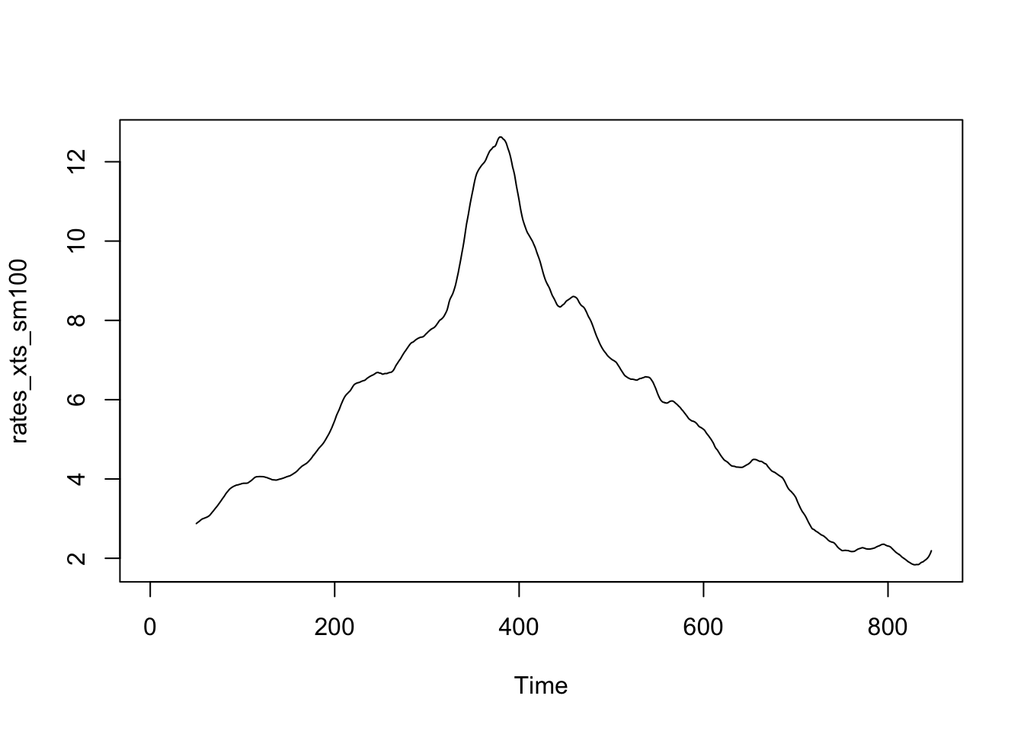

```r
library("TTR")

rates_xts_sm100 <- SMA(rates_xts, n = 50)
plot.ts(rates_xts_sm100)
```

## Check for Seasonality

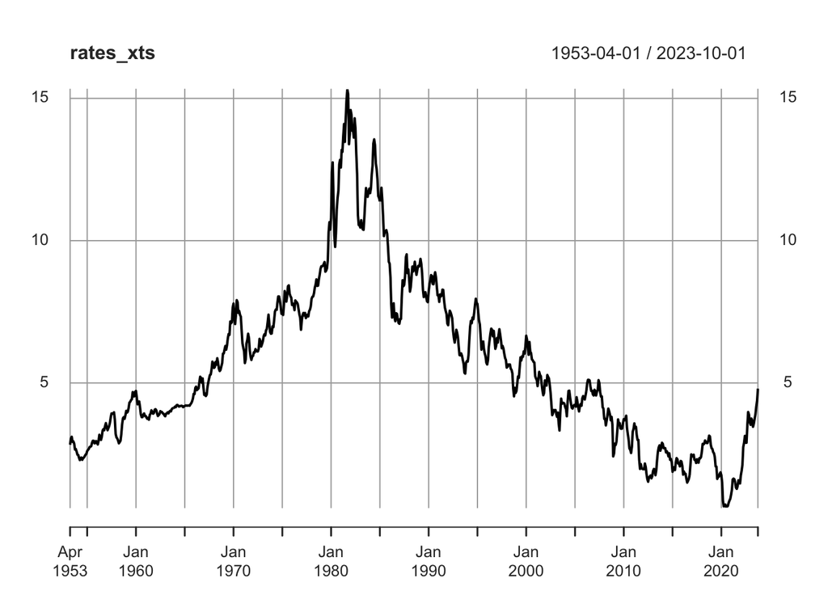

```r
plot(rates_xts)
```

```r
# dc_rates <- decompose(rates_xts) #Decompostion for Seasonality
#dc_rates$seasonal

#plot(dc_rates)
```

The data displays no seasonal components to decompose and adjust.

## Forecast with Exponential-Smoothing

```r
yields_hw <- HoltWinters(rates_xts, gamma = FALSE)
print(yields_hw) # Yield Forecasts
```

```
## Holt-Winters exponential smoothing with trend and without seasonal component.
##
## Call:
## HoltWinters(x = rates_xts, gamma = FALSE)
##
## Smoothing parameters:
##  alpha: 1
##  beta : 0.03330152
##  gamma: FALSE
##
## Coefficients:
##         [,1]
## a 4.80000000
## b 0.07337029
```

```r
print(yields_hw$SSE) #Sum of squared errors
```

```
## [1] 60.34737
```

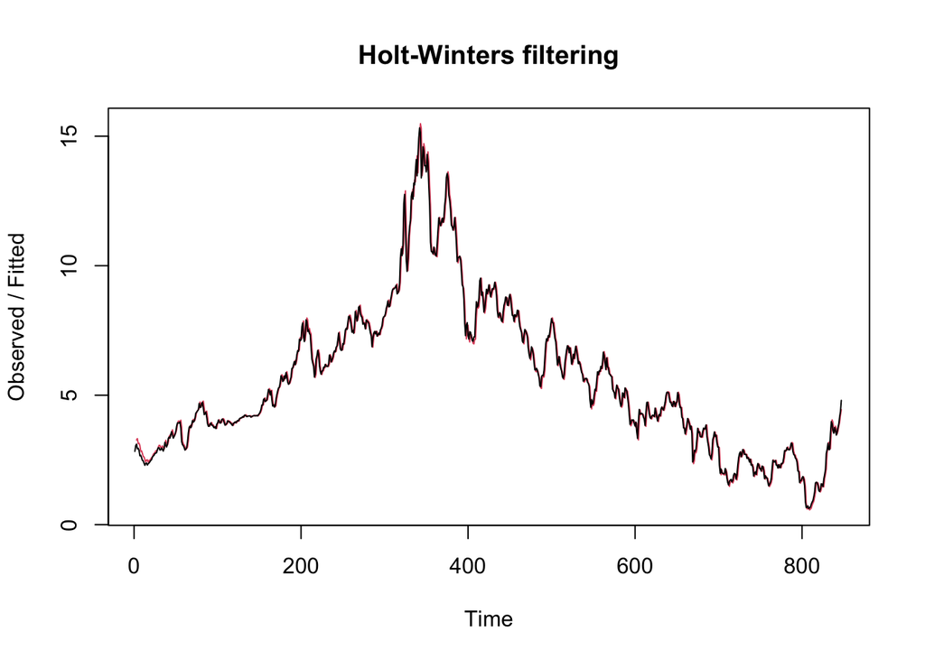

```r
plot(yields_hw)
```

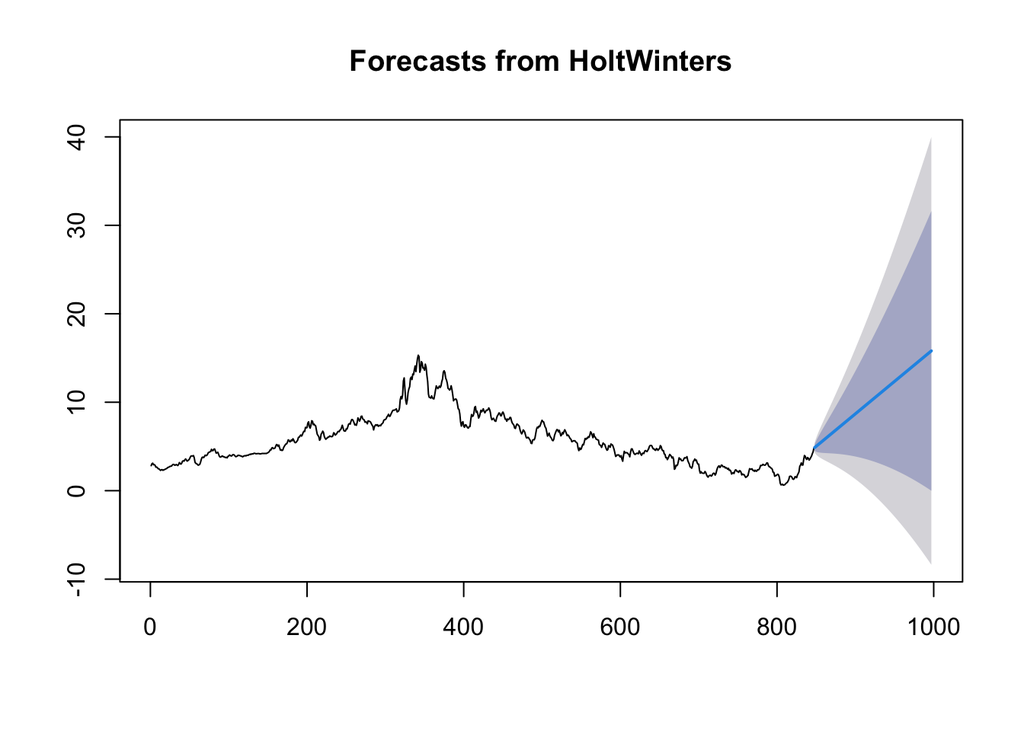

```r
yields_fc <- forecast(yields_hw, h = 150)
plot(yields_fc)
```

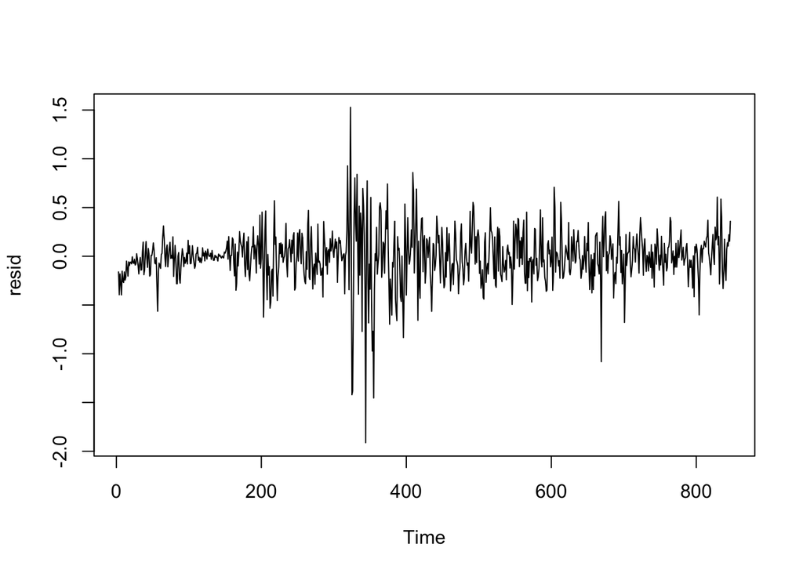

```r
resid <- yields_fc$residuals

resid <- na.omit(resid)
plot(resid)
```

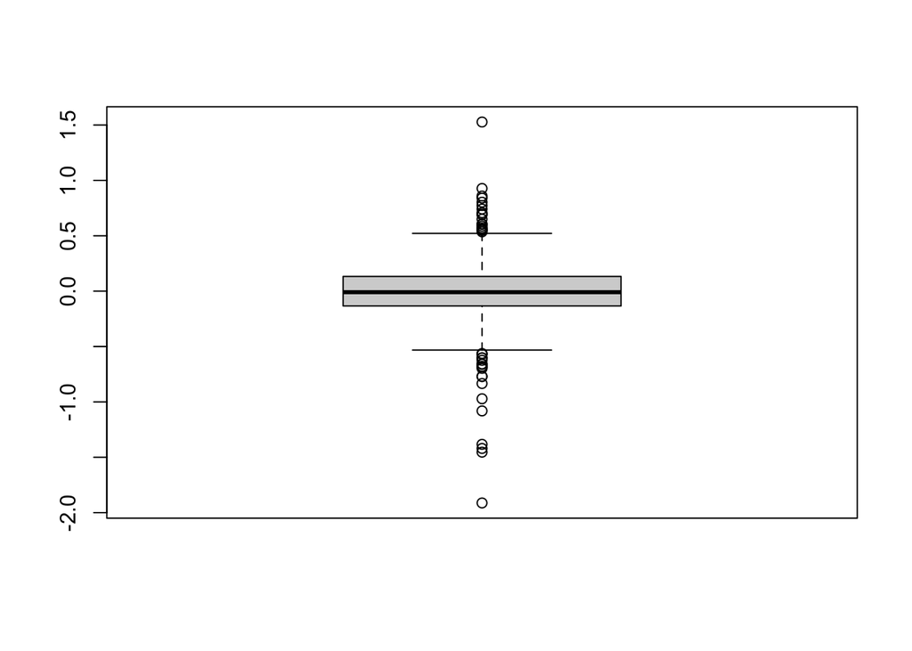

```r
boxplot(resid)
```

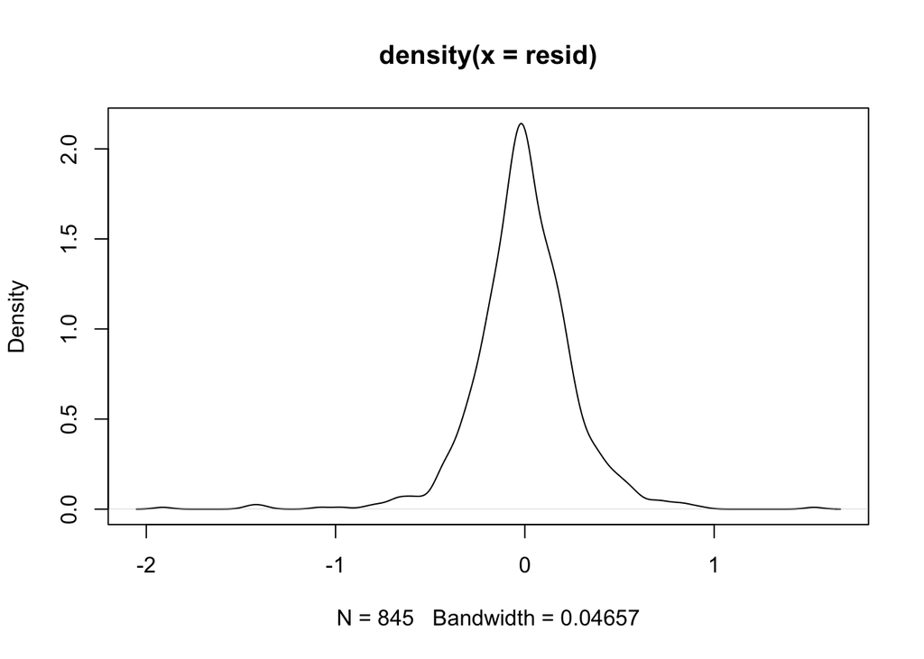

```r
resid_dens <- density(resid)
plot(resid_dens)
```

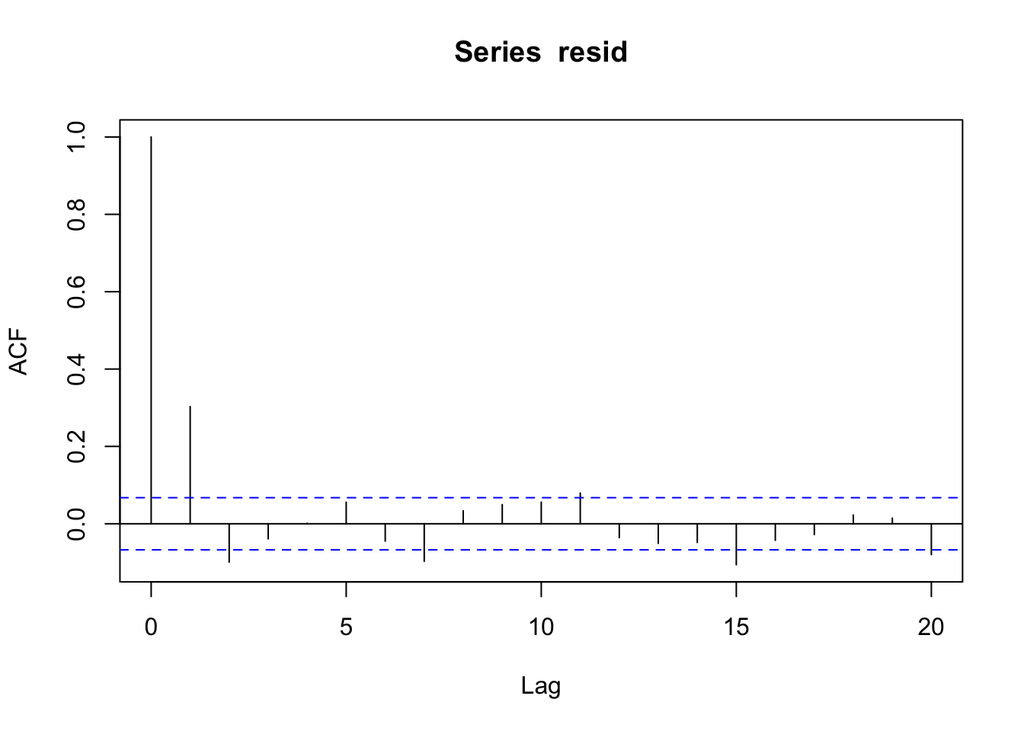

```r
acf(resid, lag.max = 20)
```

```r
Box.test(resid, lag = 20, type = "Ljung-Box")
```

```
##
##  Box-Ljung test
##
## data:  resid
## X-squared = 134.55, df = 20, p-value < 2.2e-16
```

Test something out

```r
bd_point <- length(rates_xts) - 300

# Split the data into training and test sets
back <- length(rates_xts) * 5/7
full <- length(rates_xts) * 7/7
tr_data <- rates_xts[1:back]
test_data <- rates_xts[1:full]

tr_yw <- HoltWinters(tr_data, gamma = FALSE)
print(tr_yw)
```

```
## Holt-Winters exponential smoothing with trend and without seasonal component.
##
## Call:
## HoltWinters(x = tr_data, gamma = FALSE)
##
## Smoothing parameters:
##  alpha: 1
##  beta : 0.03442452
##  gamma: FALSE
##
## Coefficients:
##          [,1]
## a  4.45000000
## b -0.01728484
```

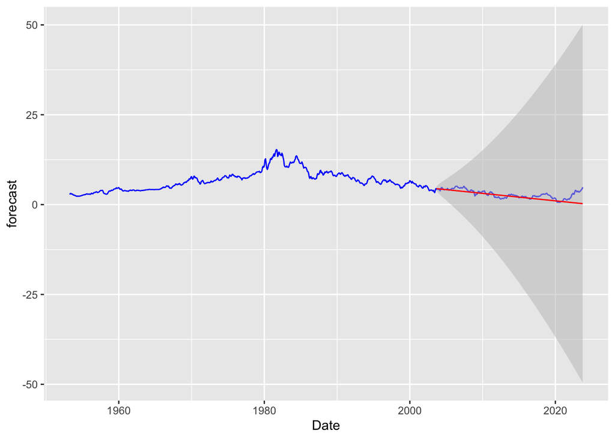

```r
tr_fc <- forecast(tr_yw, h = 242)

forecast_dates <- seq(from = as.Date("1953-04-01"), by ='month', length.out = length(rates_xts))

yield_df <- data.frame(
  Date = forecast_dates,
  forecast = rate
)

forecast_df <- data.frame(
  Date = forecast_dates[606:847],
  forecast = tr_fc$mean,
  lower = tr_fc$lower[,'95%'],
  upper = tr_fc$upper[,'95%']
)

ggplot(forecast_df, aes(x = Date, y = forecast)) +
  geom_line(data = yield_df, aes(x = Date, y = forecast), color = 'blue') +
  geom_ribbon(aes(ymin = lower, ymax = upper), fill = 'grey', alpha = 0.5) +
  geom_line(aes(y = forecast), color = 'red')
```

```r
# Calculate accuracy metrics for the forecast
accuracy_metrics_hw <- accuracy(tr_fc, test_data[606:847])

# Print out the accuracy metrics
print(accuracy_metrics_hw)
```

```
##                       ME      RMSE       MAE        MPE      MAPE     MASE
## Training set -0.01143101 0.2875369 0.1960315 -0.3730338  2.948036 1.015115
## Test set      0.57213343 1.1359713 0.7789543 16.4713358 28.251284 4.033680
##                   ACF1
## Training set 0.3125146
## Test set            NA
```

## ARIMA Modeling SECTION

We need to log the series and plot:

Usually, in time series analysis, we log transform the data in order to linearize the exponential growth pattern and reduce heteroscedasticity. In this case, if the data was presented in percentage form (0-1) rather than floating point numbers, we would have implemented the LOGIT in order to make the data stationary. However, since the data was non-stationary and exhibited level-dependent volatility, we would take the logs as an attempt to make the data mean-reverting to fit an ARIMA model.

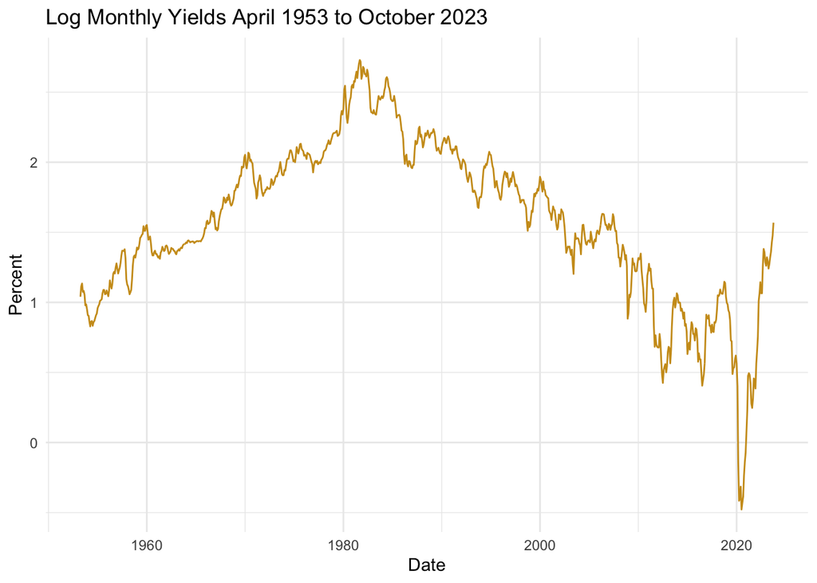

```r
#Create a new log dataframe
log_rates_df <- data.frame(Date = index(rates_xts), Rate = coredata(log(rates_xts)))

gg <- ggplot(log_rates_df, aes(x = Date, y = Rate)) +  # Specify the data and mapping of aesthetics

  # Plot the line graph with a golden color
  geom_line(color = "goldenrod3") +
  # Define titles and labels for the plot
  labs(title = "Log Monthly Yields April 1953 to October 2023", y = "Percent", x = "Date") +

  # Use a minimalistic theme for the plot
  theme_minimal()

print(gg)
```

```r
#check stationarity
station <- lapply(log_rates_df[, "Rate", drop=FALSE], adf.test, alternative="stationary", k=0)
print(station)
```

```
## $Rate
##
##  Augmented Dickey-Fuller Test
##
## data:  X[[i]]
## Dickey-Fuller = -1.9531, Lag order = 0, p-value = 0.5982
## alternative hypothesis: stationary
```

## Observations after log-transforming

Still exhibits non-stationarity. The next step would be to difference the time series. The ADF test supports this.

## Part C

ACF and PACF Methods to Establish Parameters for ARIMA.

[figure not shown]

```r
#ACF and PACF plot

acf(log_rates_df, main ="ACF of Log Gold Prices")
```

[figure not shown]

```r
pacf(log_rates_df, main = "PACF of Log Gold Prices")
```

The ACF displays a slow decay indicating non-stationarity and the series might need to be differenced. Here are the plots for the first difference:

[figure not shown]

```r
diff_log_df <- data.frame(Date = index(rates_xts), Rate = coredata(diff(log(rates_xts))))

diff_log_df <- na.omit(diff_log_df)
gg2 <- ggplot(diff_log_df, aes(x = Date, y = Rate)) +  # Specify the data and mapping of aesthetics

  # Plot the line graph with a golden color
  geom_line(color = "goldenrod3") +
  # Define titles and labels for the plot
  labs(title = "Log Diff Monthly Gold Price (2012-2023)", y = "Price", x = "Date") +

  # Use a minimalistic theme for the plot
  theme_minimal()

print(gg2)
```

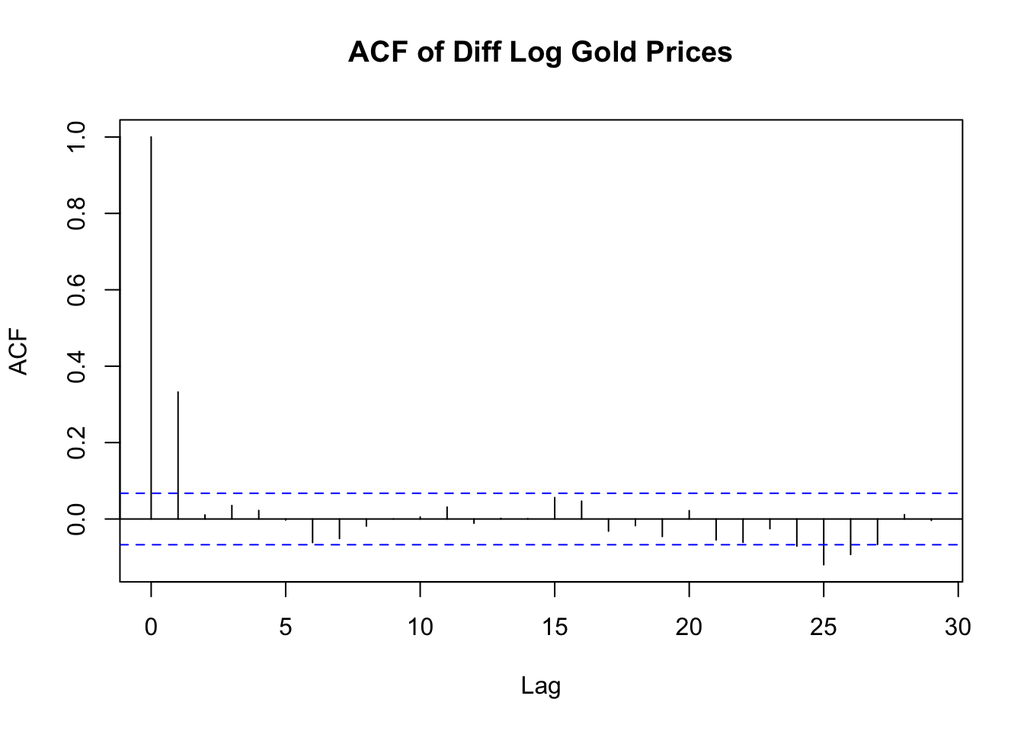

```r
#ACF and PACF plot

acf(diff_log_df$Rate[!is.na(diff_log_df$Rate)], main = "ACF of Diff Log Gold Prices")
```

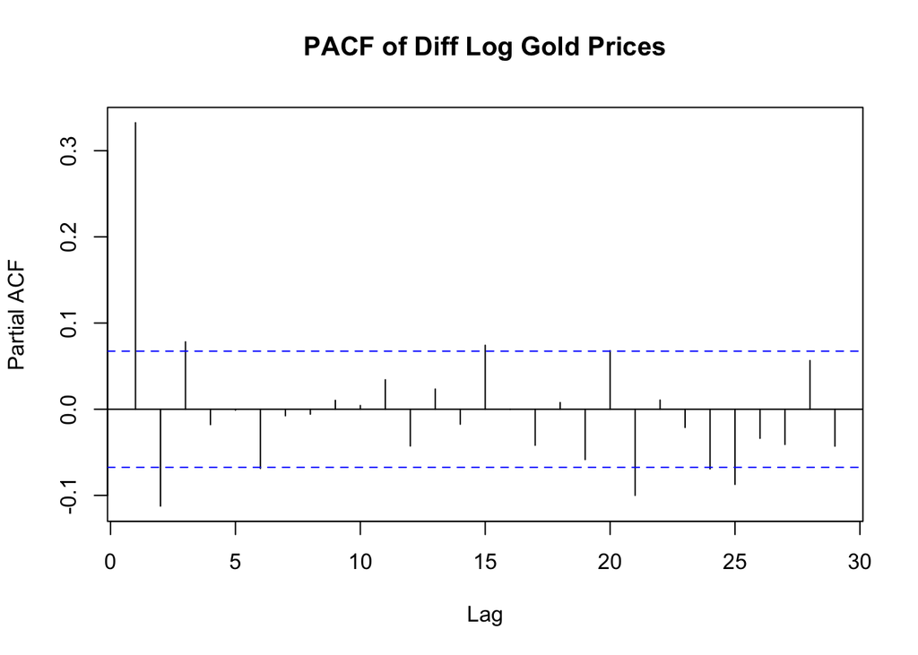

```r
pacf(diff_log_df$Rate[!is.na(diff_log_df$Rate)], main = "PACF of Diff Log Gold Prices")
```

```r
#check stationarity
station1 <- lapply(diff_log_df[, "Rate", drop=FALSE], adf.test, alternative="stationary", k=0)
print(station1)
```

```
## $Rate
##
##  Augmented Dickey-Fuller Test
##
## data:  X[[i]]
## Dickey-Fuller = -20.507, Lag order = 0, p-value = 0.01
## alternative hypothesis: stationary
```

## Observation

The ACF shows a sharp drop after lag 1. Indicative of an MA(1) process The PACF plot has a sharp drop after lag 2. Indicative of an AR(2) process The autocorrelations are quickly dying out suggesting stationarity. Hinting towards an ARIMA (2,1,1)

THE ADF Test supports that the time series is stationary, so we will not consider further differences

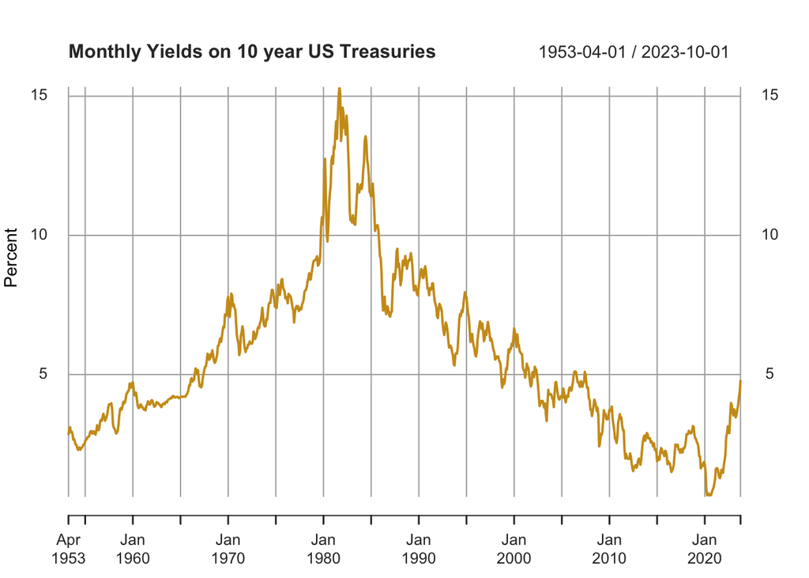

```r
# Plot xts

plot(rates_xts, main = "Monthly Yields on 10 year US Treasuries", col ="goldenrod3", xlab = "Date", ylab ="Percent")
```

```r
# Use auto.arima to find the best model
best_model <- auto.arima(rates_xts)

# To view the details of the best model
summary(best_model)
```

```
## Series: rates_xts
## ARIMA(0,1,2)
##
## Coefficients:
##          ma1      ma2
##       0.3972  -0.0942
## s.e.  0.0345   0.0349
##
## sigma^2 = 0.05983:  log likelihood = -8.25
## AIC=22.5   AICc=22.53   BIC=36.72
##
## Training set error measures:
##                       ME      RMSE       MAE         MPE     MAPE      MASE
## Training set 0.001881017 0.2441641 0.1717811 -0.05023754 3.619776 0.9465694
##                     ACF1
## Training set 0.001217537
```

## Final Model Selection

IMA(1,2) is selected by AICC and the Model does not include a constant.

## Ljung-Box Statistics for Lack of Fit

```r
# Extract residuals from the ARIMA model
residuals <- best_model$residuals


# Calculate Ljung-Box statistics for various lags
lb_stat_12 <- Box.test(residuals, lag=12, type="Ljung-Box")
lb_stat_24 <- Box.test(residuals, lag=24, type="Ljung-Box")
lb_stat_36 <- Box.test(residuals, lag=36, type="Ljung-Box")
lb_stat_48 <- Box.test(residuals, lag=48, type="Ljung-Box")

# Print the results
# Print the results
cat("Ljung-Box Test for lag 12:\n")
```

```
## Ljung-Box Test for lag 12:
```

```r
cat("Test Statistic:", lb_stat_12$statistic, "\nP-value:", lb_stat_12$p.value, "\n\n")
```

```
## Test Statistic: 25.16569
## P-value: 0.01405696
```

```r
cat("Ljung-Box Test for lag 24:\n")
```

```
## Ljung-Box Test for lag 24:
```

```r
cat("Test Statistic:", lb_stat_24$statistic, "\nP-value:", lb_stat_24$p.value, "\n\n")
```

```
## Test Statistic: 56.09655
## P-value: 0.0002223325
```

```r
cat("Ljung-Box Test for lag 36:\n")
```

```
## Ljung-Box Test for lag 36:
```

```r
cat("Test Statistic:", lb_stat_36$statistic, "\nP-value:", lb_stat_36$p.value, "\n\n")
```

```
## Test Statistic: 68.63454
## P-value: 0.0008428706
```

```r
cat("Ljung-Box Test for lag 48:\n")
```

```
## Ljung-Box Test for lag 48:
```

```r
cat("Test Statistic:", lb_stat_48$statistic, "\nP-value:", lb_stat_48$p.value, "\n\n")
```

```
## Test Statistic: 76.90544
## P-value: 0.005068995
```

## Residual, Residual ACF, and Residual PACF plot

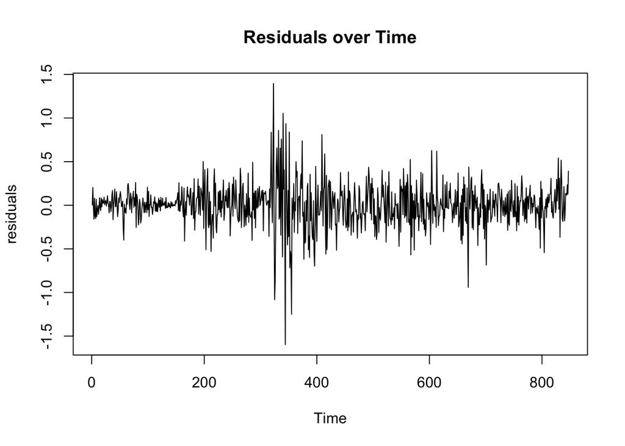

```r
# Add TS plot, ACF, and PACF

# Time series plot of residuals
ts.plot(residuals, main="Residuals over Time")
```

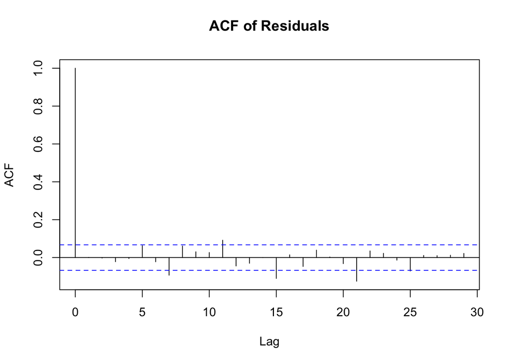

```r
# ACF of residuals
acf(residuals, main="ACF of Residuals")
```

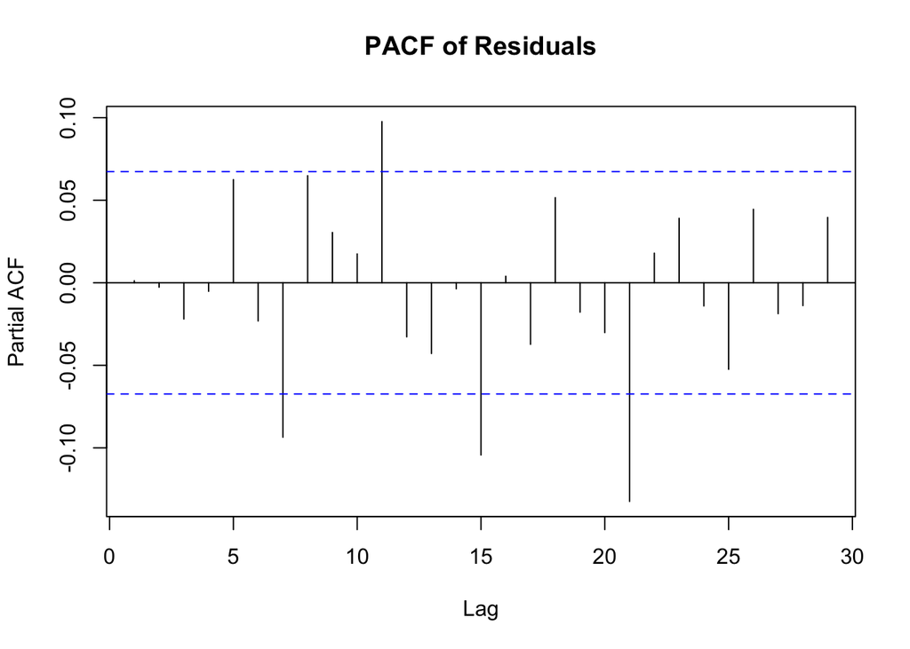

```r
# PACF of residuals
pacf(residuals, main="PACF of Residuals")
```

## Part G

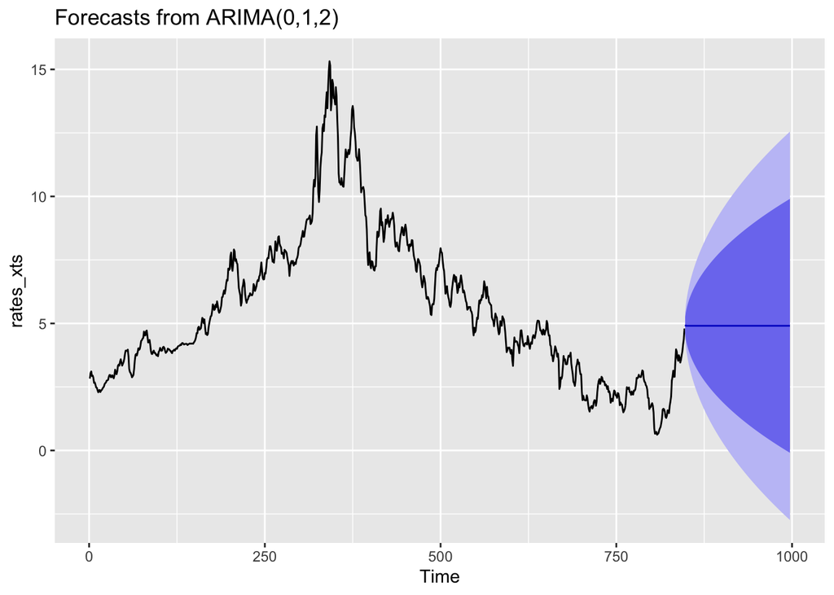

```r
# Forecasting 150 periods ahead

forecasts <- forecast(best_model, h=150)

# Plotting the forecasts
autoplot(forecasts)
```

Back-Testing ————

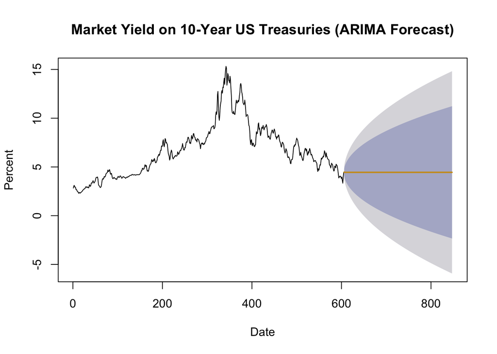

```r
# Split the data into training and test sets
back <- length(rates_xts) * 5/7
full <- length(rates_xts) * 7/7
train_data2 <- rates_xts[1:back]
test_data2 <- rates_xts[1:full]

# Fit an ARIMA model to the training data
arima_model <- auto.arima(train_data2)  # Automatically select the best ARIMA model

forecast_arima <- forecast(arima_model, h = 242)

# Plot the forecast
plot(forecast_arima, main = "Market Yield on 10-Year US Treasuries (ARIMA Forecast)", xlab = "Date", ylab = "Percent", fcol = "goldenrod3", type = "l")
```

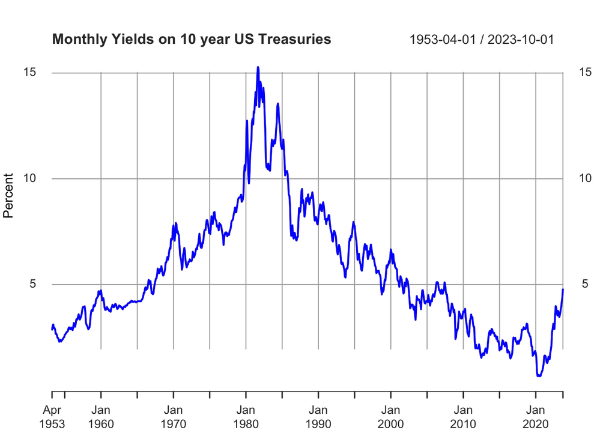

```r
# Overlay the actual time series data
lines(test_data2, col = "blue", lwd = 2)

# Add a legend
legend("topright", legend = c("ARIMA Forecast", "Actual"), col = c("goldenrod3", "blue"), lty = 1, lwd = 2)
```

```r
# Calculate accuracy metrics for the forecast
accuracy_metrics_arima <- accuracy(forecast_arima, test_data2[606:847])

# Print out the accuracy metrics
print(accuracy_metrics_arima)
```

```
##                        ME      RMSE       MAE          MPE      MAPE      MASE
## Training set  0.002036396 0.2590938 0.1797271   0.01639635  2.631428 0.9306854
## Test set     -1.523403668 1.8929078 1.5910512 -86.35484441 87.745116 8.2389826
##                     ACF1
## Training set 0.001988823
## Test set              NA
```

My evaluation of the ARIMA model’s performance through backtesting on both the training and test sets has yielded insightful results. The model demonstrates commendable fitting capability with the training data, as indicated by the low Mean Error (ME), Root Mean Squared Error (RMSE), and Mean Absolute Error (MAE). Moreover, the Mean Percentage Error (MPE) and Mean Absolute Percentage Error (MAPE) for the training set are within acceptable bounds, suggesting that the model forecasts are, on average, aligned with the historical data.

The Mean Absolute Scaled Error (MASE) for the test set further corroborates the model’s inadequate forecasting ability in comparison to a naïve benchmark. The lack of first-lag autocorrelation in the training set residuals, as shown by the ACF1 value close to zero, does not carry over to the test set, for which the ACF1 has not been reported.

These observations suggest that while the ARIMA model fits the training data well, its utility in forecasting future values is questionable. The drastic shift in performance metrics from the training to the test set implies overfitting and calls for a careful review of the model selection process. It is recommended to explore more complex models, incorporate additional explanatory variables, or apply different data transformations. This would potentially improve the model’s predictive power and generalizability to new data.

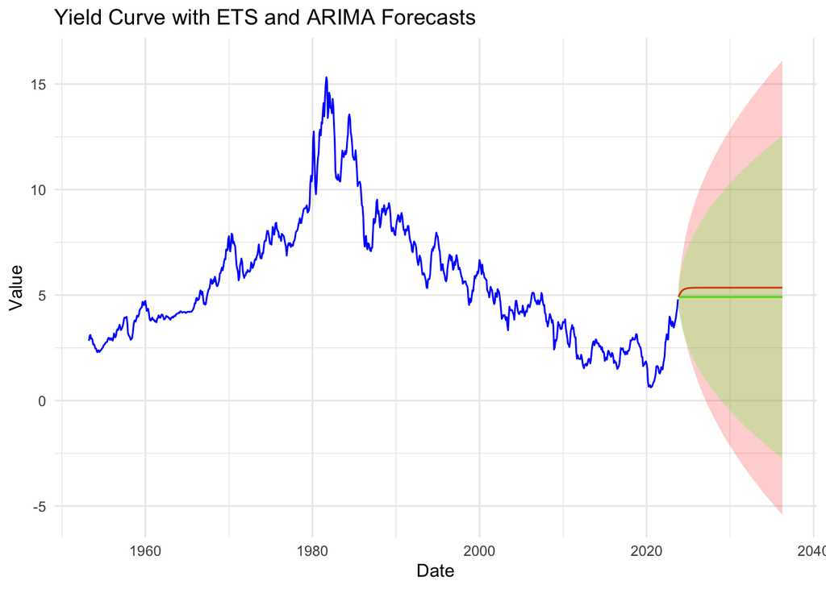

```r
fets <- function(rates_xts_,h) {
  forecast(ets(rates_xts), h = h)
}
forecast_dates1 <- seq(from = as.Date("1953-04-01"), by ='month', length.out = 997)

farima <- function(rates_xts,h)
  forecast(auto.arima(rates_xts), h = h)

fcast_ets <- fets(rates_xts, 150)

fcast_arima <- farima(rates_xts, 150)

fcast_df <- data.frame(
  Date = forecast_dates1[848:997],
  ets_forecasts = fcast_ets$mean,
  ets_lower = fcast_ets$lower[,'95%'],
  ets_upper = fcast_ets$upper[,'95%']
)
fcast_df_arima <- data.frame(
  Date = forecast_dates1[848:997],
  arima_forecasts = fcast_arima$mean,
  arima_lower = fcast_arima$lower[,'95%'],
  arima_upper = fcast_arima$upper[,'95%']
)
fcast_df <- merge(fcast_df, fcast_df_arima, by = "Date")

ggplot() +
  geom_line(data = yield_df, aes(x = Date, y = forecast), color = "blue") +
  geom_line(data = fcast_df, aes(x = Date, y = ets_forecasts), color = "red") +
  geom_line(data = fcast_df, aes(x = Date, y = arima_forecasts), color = "green") +
  geom_ribbon(data = fcast_df, aes(x = Date, ymin = ets_lower, ymax = ets_upper), fill = "red", alpha = 0.2) +
  geom_ribbon(data = fcast_df, aes(x = Date, ymin = arima_lower, ymax = arima_upper), fill = "green", alpha = 0.2) +
  labs(title = "Yield Curve with ETS and ARIMA Forecasts", x = "Date", y = "Value") +
  theme_minimal()
```